# Risk Factor Analysis

## Outcome Variable

**Outcome Variable:** ever_wasted

## Predictor Variables

**Intervention Variable:** nchldlt5

**Adjustment Set:**

- arm
- W_mage
- meducyrs
- feducyrs
- hhwealth_quart
- hfoodsec
- W_mhtcm
- W_nrooms
- W_parity
- impfloor
- impsan
- safeh20
- delta_W_mage
- delta_meducyrs
- delta_feducyrs
- delta_hhwealth_quart
- delta_hfoodsec
- delta_W_mhtcm
- delta_W_nrooms
- delta_W_parity
- delta_impfloor
- delta_impsan
- delta_safeh20

## Stratifying Variables

The analysis was stratified on these variable(s):

- agecat
- studyid
- country

## Data Summary

| agecat | studyid | country | nchldlt5 | ever_wasted | n_cell | n |
| --- | --- | --- | --- | --- | --- | --- |
| 0-24 months | ki1000108-IRC | INDIA | 1 | 0 | 25 | 291 |
| 0-24 months | ki1000108-IRC | INDIA | 1 | 1 | 64 | 291 |
| 0-24 months | ki1000108-IRC | INDIA | 2+ | 0 | 69 | 291 |
| 0-24 months | ki1000108-IRC | INDIA | 2+ | 1 | 133 | 291 |
| 0-24 months | ki1017093b-PROVIDE | BANGLADESH | 1 | 0 | 327 | 524 |
| 0-24 months | ki1017093b-PROVIDE | BANGLADESH | 1 | 1 | 185 | 524 |
| 0-24 months | ki1017093b-PROVIDE | BANGLADESH | 2+ | 0 | 6 | 524 |
| 0-24 months | ki1017093b-PROVIDE | BANGLADESH | 2+ | 1 | 6 | 524 |
| 0-24 months | ki1017093c-NIH-Crypto | BANGLADESH | 1 | 0 | 368 | 547 |
| 0-24 months | ki1017093c-NIH-Crypto | BANGLADESH | 1 | 1 | 173 | 547 |
| 0-24 months | ki1017093c-NIH-Crypto | BANGLADESH | 2+ | 0 | 4 | 547 |
| 0-24 months | ki1017093c-NIH-Crypto | BANGLADESH | 2+ | 1 | 2 | 547 |
| 0-24 months | ki1066203-TanzaniaChild2 | TANZANIA, UNITED REPUBLIC OF | 1 | 0 | 1242 | 1716 |
| 0-24 months | ki1066203-TanzaniaChild2 | TANZANIA, UNITED REPUBLIC OF | 1 | 1 | 395 | 1716 |
| 0-24 months | ki1066203-TanzaniaChild2 | TANZANIA, UNITED REPUBLIC OF | 2+ | 0 | 61 | 1716 |
| 0-24 months | ki1066203-TanzaniaChild2 | TANZANIA, UNITED REPUBLIC OF | 2+ | 1 | 18 | 1716 |
| 0-24 months | ki1112895-iLiNS-Zinc | BURKINA FASO | 1 | 0 | 838 | 1917 |
| 0-24 months | ki1112895-iLiNS-Zinc | BURKINA FASO | 1 | 1 | 235 | 1917 |
| 0-24 months | ki1112895-iLiNS-Zinc | BURKINA FASO | 2+ | 0 | 620 | 1917 |
| 0-24 months | ki1112895-iLiNS-Zinc | BURKINA FASO | 2+ | 1 | 224 | 1917 |
| 0-24 months | ki1148112-LCNI-5 | MALAWI | 1 | 0 | 366 | 454 |
| 0-24 months | ki1148112-LCNI-5 | MALAWI | 1 | 1 | 25 | 454 |
| 0-24 months | ki1148112-LCNI-5 | MALAWI | 2+ | 0 | 58 | 454 |
| 0-24 months | ki1148112-LCNI-5 | MALAWI | 2+ | 1 | 5 | 454 |
| 0-24 months | kiGH5241-JiVitA-3 | BANGLADESH | 1 | 0 | 12740 | 17858 |
| 0-24 months | kiGH5241-JiVitA-3 | BANGLADESH | 1 | 1 | 4486 | 17858 |
| 0-24 months | kiGH5241-JiVitA-3 | BANGLADESH | 2+ | 0 | 467 | 17858 |
| 0-24 months | kiGH5241-JiVitA-3 | BANGLADESH | 2+ | 1 | 165 | 17858 |
| 0-6 months | ki1000108-IRC | INDIA | 1 | 0 | 37 | 291 |
| 0-6 months | ki1000108-IRC | INDIA | 1 | 1 | 52 | 291 |
| 0-6 months | ki1000108-IRC | INDIA | 2+ | 0 | 95 | 291 |
| 0-6 months | ki1000108-IRC | INDIA | 2+ | 1 | 107 | 291 |
| 0-6 months | ki1017093b-PROVIDE | BANGLADESH | 1 | 0 | 375 | 524 |
| 0-6 months | ki1017093b-PROVIDE | BANGLADESH | 1 | 1 | 137 | 524 |
| 0-6 months | ki1017093b-PROVIDE | BANGLADESH | 2+ | 0 | 8 | 524 |
| 0-6 months | ki1017093b-PROVIDE | BANGLADESH | 2+ | 1 | 4 | 524 |
| 0-6 months | ki1017093c-NIH-Crypto | BANGLADESH | 1 | 0 | 404 | 547 |
| 0-6 months | ki1017093c-NIH-Crypto | BANGLADESH | 1 | 1 | 137 | 547 |
| 0-6 months | ki1017093c-NIH-Crypto | BANGLADESH | 2+ | 0 | 4 | 547 |
| 0-6 months | ki1017093c-NIH-Crypto | BANGLADESH | 2+ | 1 | 2 | 547 |
| 0-6 months | ki1066203-TanzaniaChild2 | TANZANIA, UNITED REPUBLIC OF | 1 | 0 | 1407 | 1716 |
| 0-6 months | ki1066203-TanzaniaChild2 | TANZANIA, UNITED REPUBLIC OF | 1 | 1 | 230 | 1716 |
| 0-6 months | ki1066203-TanzaniaChild2 | TANZANIA, UNITED REPUBLIC OF | 2+ | 0 | 64 | 1716 |
| 0-6 months | ki1066203-TanzaniaChild2 | TANZANIA, UNITED REPUBLIC OF | 2+ | 1 | 15 | 1716 |
| 0-6 months | ki1148112-LCNI-5 | MALAWI | 1 | 0 | 121 | 145 |
| 0-6 months | ki1148112-LCNI-5 | MALAWI | 1 | 1 | 1 | 145 |
| 0-6 months | ki1148112-LCNI-5 | MALAWI | 2+ | 0 | 23 | 145 |
| 0-6 months | ki1148112-LCNI-5 | MALAWI | 2+ | 1 | 0 | 145 |
| 0-6 months | kiGH5241-JiVitA-3 | BANGLADESH | 1 | 0 | 14046 | 17777 |
| 0-6 months | kiGH5241-JiVitA-3 | BANGLADESH | 1 | 1 | 3101 | 17777 |
| 0-6 months | kiGH5241-JiVitA-3 | BANGLADESH | 2+ | 0 | 521 | 17777 |
| 0-6 months | kiGH5241-JiVitA-3 | BANGLADESH | 2+ | 1 | 109 | 17777 |
| 6-24 months | ki1000108-IRC | INDIA | 1 | 0 | 56 | 291 |
| 6-24 months | ki1000108-IRC | INDIA | 1 | 1 | 33 | 291 |
| 6-24 months | ki1000108-IRC | INDIA | 2+ | 0 | 134 | 291 |
| 6-24 months | ki1000108-IRC | INDIA | 2+ | 1 | 68 | 291 |
| 6-24 months | ki1017093b-PROVIDE | BANGLADESH | 1 | 0 | 380 | 458 |
| 6-24 months | ki1017093b-PROVIDE | BANGLADESH | 1 | 1 | 68 | 458 |
| 6-24 months | ki1017093b-PROVIDE | BANGLADESH | 2+ | 0 | 8 | 458 |
| 6-24 months | ki1017093b-PROVIDE | BANGLADESH | 2+ | 1 | 2 | 458 |
| 6-24 months | ki1017093c-NIH-Crypto | BANGLADESH | 1 | 0 | 460 | 525 |
| 6-24 months | ki1017093c-NIH-Crypto | BANGLADESH | 1 | 1 | 60 | 525 |
| 6-24 months | ki1017093c-NIH-Crypto | BANGLADESH | 2+ | 0 | 4 | 525 |
| 6-24 months | ki1017093c-NIH-Crypto | BANGLADESH | 2+ | 1 | 1 | 525 |
| 6-24 months | ki1066203-TanzaniaChild2 | TANZANIA, UNITED REPUBLIC OF | 1 | 0 | 1154 | 1447 |
| 6-24 months | ki1066203-TanzaniaChild2 | TANZANIA, UNITED REPUBLIC OF | 1 | 1 | 229 | 1447 |
| 6-24 months | ki1066203-TanzaniaChild2 | TANZANIA, UNITED REPUBLIC OF | 2+ | 0 | 58 | 1447 |
| 6-24 months | ki1066203-TanzaniaChild2 | TANZANIA, UNITED REPUBLIC OF | 2+ | 1 | 6 | 1447 |
| 6-24 months | ki1112895-iLiNS-Zinc | BURKINA FASO | 1 | 0 | 838 | 1917 |
| 6-24 months | ki1112895-iLiNS-Zinc | BURKINA FASO | 1 | 1 | 235 | 1917 |
| 6-24 months | ki1112895-iLiNS-Zinc | BURKINA FASO | 2+ | 0 | 620 | 1917 |
| 6-24 months | ki1112895-iLiNS-Zinc | BURKINA FASO | 2+ | 1 | 224 | 1917 |
| 6-24 months | ki1148112-LCNI-5 | MALAWI | 1 | 0 | 360 | 446 |
| 6-24 months | ki1148112-LCNI-5 | MALAWI | 1 | 1 | 24 | 446 |
| 6-24 months | ki1148112-LCNI-5 | MALAWI | 2+ | 0 | 57 | 446 |
| 6-24 months | ki1148112-LCNI-5 | MALAWI | 2+ | 1 | 5 | 446 |
| 6-24 months | kiGH5241-JiVitA-3 | BANGLADESH | 1 | 0 | 9417 | 11579 |
| 6-24 months | kiGH5241-JiVitA-3 | BANGLADESH | 1 | 1 | 1787 | 11579 |
| 6-24 months | kiGH5241-JiVitA-3 | BANGLADESH | 2+ | 0 | 307 | 11579 |
| 6-24 months | kiGH5241-JiVitA-3 | BANGLADESH | 2+ | 1 | 68 | 11579 |

The following strata were considered:

- agecat: 0-24 months, studyid: ki1000108-IRC, country: INDIA
- agecat: 0-24 months, studyid: ki1017093b-PROVIDE, country: BANGLADESH
- agecat: 0-24 months, studyid: ki1017093c-NIH-Crypto, country: BANGLADESH
- agecat: 0-24 months, studyid: ki1066203-TanzaniaChild2, country: TANZANIA, UNITED REPUBLIC OF
- agecat: 0-24 months, studyid: ki1112895-iLiNS-Zinc, country: BURKINA FASO
- agecat: 0-24 months, studyid: ki1148112-LCNI-5, country: MALAWI
- agecat: 0-24 months, studyid: kiGH5241-JiVitA-3, country: BANGLADESH
- agecat: 0-6 months, studyid: ki1000108-IRC, country: INDIA
- agecat: 0-6 months, studyid: ki1017093b-PROVIDE, country: BANGLADESH
- agecat: 0-6 months, studyid: ki1017093c-NIH-Crypto, country: BANGLADESH
- agecat: 0-6 months, studyid: ki1066203-TanzaniaChild2, country: TANZANIA, UNITED REPUBLIC OF
- agecat: 0-6 months, studyid: ki1148112-LCNI-5, country: MALAWI
- agecat: 0-6 months, studyid: kiGH5241-JiVitA-3, country: BANGLADESH
- agecat: 6-24 months, studyid: ki1000108-IRC, country: INDIA
- agecat: 6-24 months, studyid: ki1017093b-PROVIDE, country: BANGLADESH
- agecat: 6-24 months, studyid: ki1017093c-NIH-Crypto, country: BANGLADESH
- agecat: 6-24 months, studyid: ki1066203-TanzaniaChild2, country: TANZANIA, UNITED REPUBLIC OF
- agecat: 6-24 months, studyid: ki1112895-iLiNS-Zinc, country: BURKINA FASO
- agecat: 6-24 months, studyid: ki1148112-LCNI-5, country: MALAWI
- agecat: 6-24 months, studyid: kiGH5241-JiVitA-3, country: BANGLADESH

### Dropped Strata

Some strata were dropped due to rare outcomes:

- agecat: 0-24 months, studyid: ki1017093c-NIH-Crypto, country: BANGLADESH
- agecat: 0-6 months, studyid: ki1017093b-PROVIDE, country: BANGLADESH
- agecat: 0-6 months, studyid: ki1017093c-NIH-Crypto, country: BANGLADESH
- agecat: 0-6 months, studyid: ki1148112-LCNI-5, country: MALAWI
- agecat: 6-24 months, studyid: ki1017093b-PROVIDE, country: BANGLADESH
- agecat: 6-24 months, studyid: ki1017093c-NIH-Crypto, country: BANGLADESH

## Methods Detail

We’re interested in the causal parameters $E[Y_a]$ for all values of $a \in \mathcal{A}$. These parameters represent the mean outcome if, possibly contrary to fact, we intervened to set all units to have $A=a$. Under the randomization and positivity assumptions, these are identified by the statistical parameters $\psi_a=E_W[E_{Y|A,W}(Y|A=a,W)]$. In addition, we’re interested in the mean of $Y$, $E[Y]$ under no intervention (the observed mean). We will estimate these parameters by using SuperLearner to fit the relevant likelihood factors – $E_{Y|A,W}(Y|A=a,W)$ and $p(A=a|W)$, and then updating our likelihood fit using a joint TMLE.

For unadjusted analyses ($W=\{\}$), initial likelihoods were estimated using Lrnr_glm to estimate the simple $E(Y|A)$ and Lrnr_mean to estimate $p(A)$. For adjusted analyses, a small library containing Lrnr_glmnet, Lrnr_xgboost, and Lrnr_mean was used.

Having estimated these parameters, we will then use the delta method to estimate relative risks and attributable risks relative to a prespecified baseline level of $A$.

# Results Detail

## Results Plots

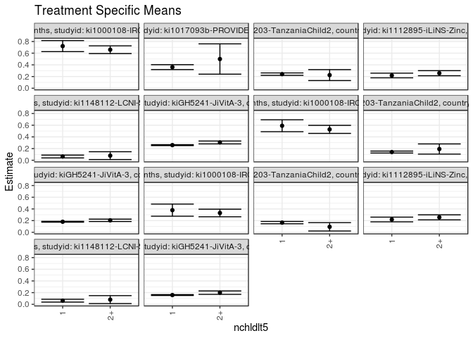

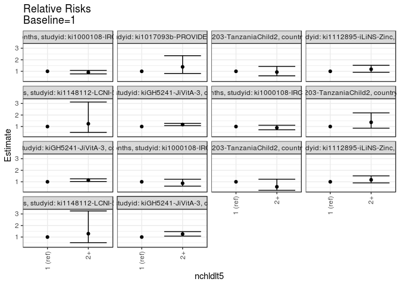

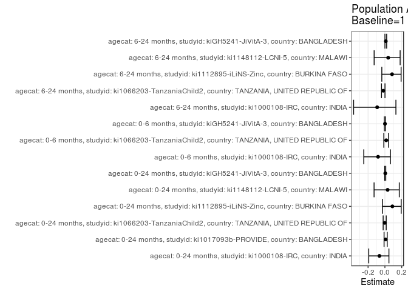

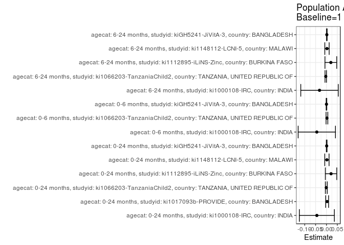

## Results Table

### Parameter: TSM

| agecat | studyid | country | intervention_level | baseline_level | estimate | ci_lower | ci_upper |
| --- | --- | --- | --- | --- | --- | --- | --- |
| 0-24 months | ki1000108-IRC | INDIA | 1 | NA | 0.7211516 | 0.6267229 | 0.8155804 |
| 0-24 months | ki1000108-IRC | INDIA | 2+ | NA | 0.6594009 | 0.5934889 | 0.7253129 |
| 0-24 months | ki1017093b-PROVIDE | BANGLADESH | 1 | NA | 0.3613281 | 0.3195882 | 0.4030681 |
| 0-24 months | ki1017093b-PROVIDE | BANGLADESH | 2+ | NA | 0.5000000 | 0.2406106 | 0.7593894 |
| 0-24 months | ki1066203-TanzaniaChild2 | TANZANIA, UNITED REPUBLIC OF | 1 | NA | 0.2412872 | 0.2205524 | 0.2620221 |
| 0-24 months | ki1066203-TanzaniaChild2 | TANZANIA, UNITED REPUBLIC OF | 2+ | NA | 0.2251013 | 0.1315280 | 0.3186746 |
| 0-24 months | ki1112895-iLiNS-Zinc | BURKINA FASO | 1 | NA | 0.2181421 | 0.1785214 | 0.2577629 |
| 0-24 months | ki1112895-iLiNS-Zinc | BURKINA FASO | 2+ | NA | 0.2575909 | 0.2142883 | 0.3008934 |
| 0-24 months | ki1148112-LCNI-5 | MALAWI | 1 | NA | 0.0639386 | 0.0396629 | 0.0882144 |
| 0-24 months | ki1148112-LCNI-5 | MALAWI | 2+ | NA | 0.0793651 | 0.0125438 | 0.1461864 |
| 0-24 months | kiGH5241-JiVitA-3 | BANGLADESH | 1 | NA | 0.2593377 | 0.2515404 | 0.2671350 |
| 0-24 months | kiGH5241-JiVitA-3 | BANGLADESH | 2+ | NA | 0.3046528 | 0.2801312 | 0.3291744 |
| 0-6 months | ki1000108-IRC | INDIA | 1 | NA | 0.5908066 | 0.4886004 | 0.6930129 |
| 0-6 months | ki1000108-IRC | INDIA | 2+ | NA | 0.5286472 | 0.4595727 | 0.5977216 |
| 0-6 months | ki1066203-TanzaniaChild2 | TANZANIA, UNITED REPUBLIC OF | 1 | NA | 0.1405065 | 0.1236668 | 0.1573461 |
| 0-6 months | ki1066203-TanzaniaChild2 | TANZANIA, UNITED REPUBLIC OF | 2+ | NA | 0.1924305 | 0.1053530 | 0.2795080 |
| 0-6 months | kiGH5241-JiVitA-3 | BANGLADESH | 1 | NA | 0.1804275 | 0.1735396 | 0.1873155 |
| 0-6 months | kiGH5241-JiVitA-3 | BANGLADESH | 2+ | NA | 0.2049062 | 0.1845884 | 0.2252240 |
| 6-24 months | ki1000108-IRC | INDIA | 1 | NA | 0.3790123 | 0.2752566 | 0.4827680 |
| 6-24 months | ki1000108-IRC | INDIA | 2+ | NA | 0.3306275 | 0.2656383 | 0.3956167 |
| 6-24 months | ki1066203-TanzaniaChild2 | TANZANIA, UNITED REPUBLIC OF | 1 | NA | 0.1655821 | 0.1459852 | 0.1851789 |
| 6-24 months | ki1066203-TanzaniaChild2 | TANZANIA, UNITED REPUBLIC OF | 2+ | NA | 0.0937500 | 0.0223139 | 0.1651861 |
| 6-24 months | ki1112895-iLiNS-Zinc | BURKINA FASO | 1 | NA | 0.2191128 | 0.1791347 | 0.2590910 |
| 6-24 months | ki1112895-iLiNS-Zinc | BURKINA FASO | 2+ | NA | 0.2564823 | 0.2137600 | 0.2992047 |
| 6-24 months | ki1148112-LCNI-5 | MALAWI | 1 | NA | 0.0625000 | 0.0382621 | 0.0867379 |
| 6-24 months | ki1148112-LCNI-5 | MALAWI | 2+ | NA | 0.0806452 | 0.0127919 | 0.1484984 |
| 6-24 months | kiGH5241-JiVitA-3 | BANGLADESH | 1 | NA | 0.1584830 | 0.1510124 | 0.1659535 |
| 6-24 months | kiGH5241-JiVitA-3 | BANGLADESH | 2+ | NA | 0.1996795 | 0.1706444 | 0.2287145 |

### Parameter: E(Y)

| agecat | studyid | country | intervention_level | baseline_level | estimate | ci_lower | ci_upper |
| --- | --- | --- | --- | --- | --- | --- | --- |
| 0-24 months | ki1000108-IRC | INDIA | NA | NA | 0.6769759 | 0.6231548 | 0.7307971 |
| 0-24 months | ki1017093b-PROVIDE | BANGLADESH | NA | NA | 0.3645038 | 0.3232556 | 0.4057520 |
| 0-24 months | ki1066203-TanzaniaChild2 | TANZANIA, UNITED REPUBLIC OF | NA | NA | 0.2406760 | 0.2204437 | 0.2609083 |
| 0-24 months | ki1112895-iLiNS-Zinc | BURKINA FASO | NA | NA | 0.2394366 | 0.2104280 | 0.2684452 |
| 0-24 months | ki1148112-LCNI-5 | MALAWI | NA | NA | 0.0660793 | 0.0432029 | 0.0889556 |
| 0-24 months | kiGH5241-JiVitA-3 | BANGLADESH | NA | NA | 0.2604435 | 0.2529356 | 0.2679514 |
| 0-6 months | ki1000108-IRC | INDIA | NA | NA | 0.5463918 | 0.4890935 | 0.6036900 |
| 0-6 months | ki1066203-TanzaniaChild2 | TANZANIA, UNITED REPUBLIC OF | NA | NA | 0.1427739 | 0.1262166 | 0.1593311 |
| 0-6 months | kiGH5241-JiVitA-3 | BANGLADESH | NA | NA | 0.1805704 | 0.1739574 | 0.1871834 |
| 6-24 months | ki1000108-IRC | INDIA | NA | NA | 0.3470790 | 0.2922900 | 0.4018681 |
| 6-24 months | ki1066203-TanzaniaChild2 | TANZANIA, UNITED REPUBLIC OF | NA | NA | 0.1624050 | 0.1433950 | 0.1814149 |
| 6-24 months | ki1112895-iLiNS-Zinc | BURKINA FASO | NA | NA | 0.2394366 | 0.2104280 | 0.2684452 |
| 6-24 months | ki1148112-LCNI-5 | MALAWI | NA | NA | 0.0650224 | 0.0421137 | 0.0879311 |
| 6-24 months | kiGH5241-JiVitA-3 | BANGLADESH | NA | NA | 0.1602038 | 0.1529875 | 0.1674201 |

### Parameter: RR

| agecat | studyid | country | intervention_level | baseline_level | estimate | ci_lower | ci_upper |
| --- | --- | --- | --- | --- | --- | --- | --- |
| 0-24 months | ki1000108-IRC | INDIA | 1 | 1 | 1.0000000 | 1.0000000 | 1.000000 |
| 0-24 months | ki1000108-IRC | INDIA | 2+ | 1 | 0.9143721 | 0.7752813 | 1.078417 |
| 0-24 months | ki1017093b-PROVIDE | BANGLADESH | 1 | 1 | 1.0000000 | 1.0000000 | 1.000000 |
| 0-24 months | ki1017093b-PROVIDE | BANGLADESH | 2+ | 1 | 1.3837838 | 0.8132937 | 2.354448 |
| 0-24 months | ki1066203-TanzaniaChild2 | TANZANIA, UNITED REPUBLIC OF | 1 | 1 | 1.0000000 | 1.0000000 | 1.000000 |
| 0-24 months | ki1066203-TanzaniaChild2 | TANZANIA, UNITED REPUBLIC OF | 2+ | 1 | 0.9329183 | 0.6101742 | 1.426374 |
| 0-24 months | ki1112895-iLiNS-Zinc | BURKINA FASO | 1 | 1 | 1.0000000 | 1.0000000 | 1.000000 |
| 0-24 months | ki1112895-iLiNS-Zinc | BURKINA FASO | 2+ | 1 | 1.1808396 | 0.9176790 | 1.519466 |
| 0-24 months | ki1148112-LCNI-5 | MALAWI | 1 | 1 | 1.0000000 | 1.0000000 | 1.000000 |
| 0-24 months | ki1148112-LCNI-5 | MALAWI | 2+ | 1 | 1.2412698 | 0.4928942 | 3.125926 |
| 0-24 months | kiGH5241-JiVitA-3 | BANGLADESH | 1 | 1 | 1.0000000 | 1.0000000 | 1.000000 |
| 0-24 months | kiGH5241-JiVitA-3 | BANGLADESH | 2+ | 1 | 1.1747338 | 1.0805285 | 1.277152 |
| 0-6 months | ki1000108-IRC | INDIA | 1 | 1 | 1.0000000 | 1.0000000 | 1.000000 |
| 0-6 months | ki1000108-IRC | INDIA | 2+ | 1 | 0.8947888 | 0.7198963 | 1.112170 |
| 0-6 months | ki1066203-TanzaniaChild2 | TANZANIA, UNITED REPUBLIC OF | 1 | 1 | 1.0000000 | 1.0000000 | 1.000000 |
| 0-6 months | ki1066203-TanzaniaChild2 | TANZANIA, UNITED REPUBLIC OF | 2+ | 1 | 1.3695494 | 0.8576116 | 2.187081 |
| 0-6 months | kiGH5241-JiVitA-3 | BANGLADESH | 1 | 1 | 1.0000000 | 1.0000000 | 1.000000 |
| 0-6 months | kiGH5241-JiVitA-3 | BANGLADESH | 2+ | 1 | 1.1356703 | 1.0250153 | 1.258271 |
| 6-24 months | ki1000108-IRC | INDIA | 1 | 1 | 1.0000000 | 1.0000000 | 1.000000 |
| 6-24 months | ki1000108-IRC | INDIA | 2+ | 1 | 0.8723398 | 0.6231818 | 1.221115 |
| 6-24 months | ki1066203-TanzaniaChild2 | TANZANIA, UNITED REPUBLIC OF | 1 | 1 | 1.0000000 | 1.0000000 | 1.000000 |
| 6-24 months | ki1066203-TanzaniaChild2 | TANZANIA, UNITED REPUBLIC OF | 2+ | 1 | 0.5661845 | 0.2618570 | 1.224198 |
| 6-24 months | ki1112895-iLiNS-Zinc | BURKINA FASO | 1 | 1 | 1.0000000 | 1.0000000 | 1.000000 |
| 6-24 months | ki1112895-iLiNS-Zinc | BURKINA FASO | 2+ | 1 | 1.1705491 | 0.9055621 | 1.513077 |
| 6-24 months | ki1148112-LCNI-5 | MALAWI | 1 | 1 | 1.0000000 | 1.0000000 | 1.000000 |
| 6-24 months | ki1148112-LCNI-5 | MALAWI | 2+ | 1 | 1.2903226 | 0.5109108 | 3.258753 |
| 6-24 months | kiGH5241-JiVitA-3 | BANGLADESH | 1 | 1 | 1.0000000 | 1.0000000 | 1.000000 |
| 6-24 months | kiGH5241-JiVitA-3 | BANGLADESH | 2+ | 1 | 1.2599426 | 1.0810125 | 1.468489 |

### Parameter: PAR

| agecat | studyid | country | intervention_level | baseline_level | estimate | ci_lower | ci_upper |
| --- | --- | --- | --- | --- | --- | --- | --- |
| 0-24 months | ki1000108-IRC | INDIA | 1 | NA | -0.0441757 | -0.1248514 | 0.0365000 |
| 0-24 months | ki1017093b-PROVIDE | BANGLADESH | 1 | NA | 0.0031757 | -0.0036288 | 0.0099802 |
| 0-24 months | ki1066203-TanzaniaChild2 | TANZANIA, UNITED REPUBLIC OF | 1 | NA | -0.0006112 | -0.0049897 | 0.0037672 |
| 0-24 months | ki1112895-iLiNS-Zinc | BURKINA FASO | 1 | NA | 0.0212945 | -0.0050950 | 0.0476840 |
| 0-24 months | ki1148112-LCNI-5 | MALAWI | 1 | NA | 0.0021407 | -0.0077370 | 0.0120184 |
| 0-24 months | kiGH5241-JiVitA-3 | BANGLADESH | 1 | NA | 0.0011058 | -0.0005272 | 0.0027388 |
| 0-6 months | ki1000108-IRC | INDIA | 1 | NA | -0.0444149 | -0.1303891 | 0.0415594 |
| 0-6 months | ki1066203-TanzaniaChild2 | TANZANIA, UNITED REPUBLIC OF | 1 | NA | 0.0022674 | -0.0018150 | 0.0063499 |
| 0-6 months | kiGH5241-JiVitA-3 | BANGLADESH | 1 | NA | 0.0001429 | -0.0012886 | 0.0015744 |
| 6-24 months | ki1000108-IRC | INDIA | 1 | NA | -0.0319333 | -0.1183473 | 0.0544807 |
| 6-24 months | ki1066203-TanzaniaChild2 | TANZANIA, UNITED REPUBLIC OF | 1 | NA | -0.0031771 | -0.0065407 | 0.0001865 |
| 6-24 months | ki1112895-iLiNS-Zinc | BURKINA FASO | 1 | NA | 0.0203238 | -0.0068901 | 0.0475377 |
| 6-24 months | ki1148112-LCNI-5 | MALAWI | 1 | NA | 0.0025224 | -0.0075108 | 0.0125556 |
| 6-24 months | kiGH5241-JiVitA-3 | BANGLADESH | 1 | NA | 0.0017208 | 0.0000896 | 0.0033521 |

### Parameter: PAF

| agecat | studyid | country | intervention_level | baseline_level | estimate | ci_lower | ci_upper |
| --- | --- | --- | --- | --- | --- | --- | --- |
| 0-24 months | ki1000108-IRC | INDIA | 1 | NA | -0.0652544 | -0.1917987 | 0.0478534 |
| 0-24 months | ki1017093b-PROVIDE | BANGLADESH | 1 | NA | 0.0087124 | -0.0101490 | 0.0272216 |
| 0-24 months | ki1066203-TanzaniaChild2 | TANZANIA, UNITED REPUBLIC OF | 1 | NA | -0.0025396 | -0.0208975 | 0.0154881 |
| 0-24 months | ki1112895-iLiNS-Zinc | BURKINA FASO | 1 | NA | 0.0889359 | -0.0290680 | 0.1934082 |
| 0-24 months | ki1148112-LCNI-5 | MALAWI | 1 | NA | 0.0323956 | -0.1288281 | 0.1705926 |
| 0-24 months | kiGH5241-JiVitA-3 | BANGLADESH | 1 | NA | 0.0042458 | -0.0020542 | 0.0105062 |
| 0-6 months | ki1000108-IRC | INDIA | 1 | NA | -0.0812876 | -0.2511568 | 0.0655185 |
| 0-6 months | ki1066203-TanzaniaChild2 | TANZANIA, UNITED REPUBLIC OF | 1 | NA | 0.0158813 | -0.0130916 | 0.0440255 |
| 0-6 months | kiGH5241-JiVitA-3 | BANGLADESH | 1 | NA | 0.0007913 | -0.0071705 | 0.0086902 |
| 6-24 months | ki1000108-IRC | INDIA | 1 | NA | -0.0920058 | -0.3716113 | 0.1306017 |
| 6-24 months | ki1066203-TanzaniaChild2 | TANZANIA, UNITED REPUBLIC OF | 1 | NA | -0.0195628 | -0.0404074 | 0.0008642 |
| 6-24 months | ki1112895-iLiNS-Zinc | BURKINA FASO | 1 | NA | 0.0848817 | -0.0367806 | 0.1922673 |
| 6-24 months | ki1148112-LCNI-5 | MALAWI | 1 | NA | 0.0387931 | -0.1279697 | 0.1809011 |
| 6-24 months | kiGH5241-JiVitA-3 | BANGLADESH | 1 | NA | 0.0107416 | 0.0004727 | 0.0209049 |